# Responses to reviewers: figures

Daijiang Li, Anthony Ives

24 January, 2017

To respond to reviewer 2’s major comment about how the topology of the phylogenies will affect the results and conclusions of our manuscript, we have

1. re-done all analyses with symmetrical balanced phylogenies;
2. compared type I errors of LMM and PLMM when phylogenies were simulated with simple birth-death model but with different death rates.

Overall, the results are very similar to those from the manuscript. Therefore, the phylogenies do not affect our results and conclusions.

# Re-do all analyses

We have re-done all analyses with symmetrical balanced phylogenies, using the `ape::stree(n = nspp, type = "balanced")` R function. Instead of simulating 1000 datasets for each combination of `nspp`, `beta_5`, and `trait1: I/C, trait2: I/C`, we only simulated 200 datasets for each combination of `nspp = c(16, 32, 64)`, `beta_5 = c(0, 0.5, 1)`, and the same traits conditions.

Here are the figures resulted from simulations with balanced phylogenies. They show the same pattern as those in the manuscript.

```r
library(plyr)
library(dplyr)
library(tidyr)
library(ggplot2)
library(cowplot)
library(viridis)

## read rds files from type I errors: varied nspp ----
rdss1 = list.files("rds_symm", full.names = T)
sim.FE1 = vector("list", length = length(rdss1))
for (i in 1:length(rdss1)){
  sim.FE1[[i]] = readRDS(file = rdss1[i])$est.fixed.eff %>%
    mutate(nspp = as.numeric(gsub("^.*sp([0-9]{2})site.*$", "\\1", rdss1[i])),
           nsite = as.numeric(gsub("^.*site([0-9]{2}).*$", "\\1", rdss1[i])),
           catg = gsub("^.*_([0-9]{2}).*$", "\\1", rdss1[i]))
}
sim.FE1 = tbl_df(ldply(sim.FE1)) %>% filter(terms == "envi1:trait1")

prop_better1 = sim.FE1 %>%
  select(estimate, trt, real.val, item, nspp, catg) %>%
  mutate(diff = abs(estimate - real.val)) %>%
  select(-estimate) %>%
  spread(key = trt, value = diff)
prop_better1 = adply(prop_better1, 1, function(x){# take a while
  if(x[5] > x[6]) better_trt = "phylo"
  if(x[5] < x[6]) better_trt = "no_phylo"
  if(x[5] == x[6]) better_trt = sample(c("phylo", "no_phylo"), 1)
  better_trt
})
prop_better1 = prop_better1 %>% tbl_df() %>%
  select(nspp, catg, V1) %>%
  group_by(nspp, catg) %>%
  summarise(PLMM = sum(V1 == "phylo")/max(sim.FE1$item),
            LMM = sum(V1 == "no_phylo")/max(sim.FE1$item)) %>%
  gather(key = "Models", value = "prop", PLMM, LMM) %>%
  ungroup() %>%
  mutate(nspp = as.character(nspp))
prop_better1$catg[prop_better1$catg == "00"] = "trait1: I; trait2: I"
prop_better1$catg[prop_better1$catg == "01"] = "trait1: I; trait2: C"
prop_better1$catg[prop_better1$catg == "10"] = "trait1: C; trait2: I"
prop_better1$catg[prop_better1$catg == "11"] = "trait1: C; trait2: C"
prop_better1$catg = factor(prop_better1$catg,
                           levels = c("trait1: I; trait2: I",
                                      "trait1: C; trait2: I",
                                      "trait1: I; trait2: C",
                                      "trait1: C; trait2: C"))
prop_better1$Models[prop_better1$Models == "PLMM"] = "PLMM better"
prop_better1$Models[prop_better1$Models == "LMM"] = "LMM better"
# data to plot type I error
type_errs = sim.FE1 %>%
  group_by(trt, nspp, nsite, catg) %>%
  summarise(nitem = max(item),
            mid.est = median(estimate),
            ave.est = mean(estimate),
            ave.est.low = mean(estimate) - 1 * sd(estimate),
            ave.est.high = mean(estimate) + 1 * sd(estimate),
            reject.prop = sum(Pvalue <= 0.05)/nitem) %>% ungroup()
type_errs$catg2 = type_errs$catg
type_errs$catg[type_errs$catg == "00"] = "trait1: I; trait2: I"
type_errs$catg[type_errs$catg == "01"] = "trait1: I; trait2: C"
type_errs$catg[type_errs$catg == "10"] = "trait1: C; trait2: I"
type_errs$catg[type_errs$catg == "11"] = "trait1: C; trait2: C"
type_errs$catg = factor(type_errs$catg,
                        levels = c("trait1: I; trait2: I",
                                   "trait1: C; trait2: I",
                                   "trait1: I; trait2: C",
                                   "trait1: C; trait2: C"))
type_errs = mutate(type_errs, models = trt)
type_errs$models[type_errs$models == "no_phylo"] = "LMM"
type_errs$models[type_errs$models == "phylo"] = "PLMM"


## read rds files from power / type II errors: varied beta 5 ----
rdss2 = list.files("rds_symm2", full.names = T)
sim.FE2 = vector("list", length = length(rdss2))
for (i in 1:length(rdss2)){
  sim.FE2[[i]] = readRDS(file = rdss2[i])$est.fixed.eff %>%
    mutate(nspp = as.numeric(gsub("^.*sp([0-9]{2})site.*$", "\\1", rdss2[i])),
           nsite = as.numeric(gsub("^.*site([0-9]{2}).*$", "\\1", rdss2[i])),
           beta5 = as.numeric(gsub("^.*beta_5([0-9.]{1,4}).*$", "\\1", rdss2[i])),
           catg = gsub("^.*_([0-9]{2}).*$", "\\1", rdss2[i]))
}
sim.FE2 = tbl_df(ldply(sim.FE2)) %>% filter(terms == "envi1:trait1")

prop_better2 = sim.FE2 %>%
  select(estimate, trt, real.val, item, nspp, catg) %>%
  mutate(diff = abs(estimate - real.val)) %>%
  select(-estimate) %>%
  spread(key = trt, value = diff)
prop_better2 = adply(prop_better2, 1, function(x){
  if(x[5] > x[6]) better_trt = "phylo"
  if(x[5] < x[6]) better_trt = "no_phylo"
  if(x[5] == x[6]) better_trt = sample(c("phylo", "no_phylo"), 1)
  better_trt
})
prop_better2 = prop_better2 %>% tbl_df() %>%
  select(real.val, catg, V1) %>%
  group_by(real.val, catg) %>%
  summarise(PLMM = sum(V1 == "phylo")/max(sim.FE2$item),
            LMM = sum(V1 == "no_phylo")/max(sim.FE2$item)) %>%
  gather(key = "Models", value = "prop", PLMM, LMM) %>%
  ungroup() %>%
  mutate(real.val = as.character(real.val))
prop_better2$catg[prop_better2$catg == "00"] = "trait1: I; trait2: I"
prop_better2$catg[prop_better2$catg == "01"] = "trait1: I; trait2: C"
prop_better2$catg[prop_better2$catg == "10"] = "trait1: C; trait2: I"
prop_better2$catg[prop_better2$catg == "11"] = "trait1: C; trait2: C"
prop_better2$catg = factor(prop_better2$catg,
                           levels = c("trait1: I; trait2: I",
                                      "trait1: C; trait2: I",
                                      "trait1: I; trait2: C",
                                      "trait1: C; trait2: C"))
prop_better2$Models[prop_better2$Models == "PLMM"] = "PLMM better"
prop_better2$Models[prop_better2$Models == "LMM"] = "LMM better"

# data to plot power
type_errs2 = sim.FE2 %>%
  group_by(trt, beta5, catg) %>%
  summarise(nitem = max(item),
            mid.est = median(estimate),
            ave.est = mean(estimate),
            ave.est.low = mean(estimate) - 1 * sd(estimate),
            ave.est.high = mean(estimate) + 1 * sd(estimate),
            reject.prop = sum(Pvalue <= 0.05)/nitem) %>%
  ungroup()
type_errs2$catg[type_errs2$catg == "00"] = "trait1: I; trait2: I"
type_errs2$catg[type_errs2$catg == "01"] = "trait1: I; trait2: C"
type_errs2$catg[type_errs2$catg == "10"] = "trait1: C; trait2: I"
type_errs2$catg[type_errs2$catg == "11"] = "trait1: C; trait2: C"
type_errs2$catg = factor(type_errs2$catg,
                         levels = c("trait1: I; trait2: I",
                                    "trait1: C; trait2: I",
                                    "trait1: I; trait2: C",
                                    "trait1: C; trait2: C"))
type_errs2 = mutate(type_errs2, models = trt)
type_errs2$models[type_errs2$models == "no_phylo"] = "LMM"
type_errs2$models[type_errs2$models == "phylo"] = "PLMM"

# function to plot fig. 4 ----
#' nsp: number of species in the simulation
#' nitem: how many simulations to plot?
#' alpha: transparency
#' trait2_C: only plot trait2: C?
#' text1_x: location of LMM text
#' text1_y: location of LMM text
#' text2_x: location of PLMM text
#' text2_y: location of PLMM text
est_se_plt = function(nsp = c(50, 20, 40, 60, 80), nitem = NULL, alpha = 1,
                      trait2_C = TRUE, text1_x = 0.765, text2_x = 0.75,
                      text1_y = 0.07, text2_y = 0.05){
  nspp_est_se_0 = filter(sim.FE1, nspp == nsp)
  if(!is.null(nitem)){ # to plot less points
    idex = sample(1:max(nspp_est_se_0$item), size = nitem, replace = F)
    nspp_est_se = filter(nspp_est_se_0, item %in% idex)
  } else {
    nspp_est_se = nspp_est_se_0
  }
  nspp_est_se$catg[nspp_est_se$catg == "00"] = "trait1: I; trait2: I"
  nspp_est_se$catg[nspp_est_se$catg == "01"] = "trait1: I; trait2: C"
  nspp_est_se$catg[nspp_est_se$catg == "10"] = "trait1: C; trait2: I"
  nspp_est_se$catg[nspp_est_se$catg == "11"] = "trait1: C; trait2: C"
  nspp_est_se$catg = factor(nspp_est_se$catg,
                            levels = c("trait1: I; trait2: I",
                                       "trait1: C; trait2: I",
                                       "trait1: I; trait2: C",
                                       "trait1: C; trait2: C"))
  nspp_est_se$trt[nspp_est_se$trt == "phylo"] = "PLMM"
  nspp_est_se$trt[nspp_est_se$trt == "no_phylo"] = "LMM"
  nspp_est_se = mutate(nspp_est_se, Significant = Pvalue < 0.05, Model = trt)

  nspp_est_se_err = group_by(mutate(nspp_est_se_0, Model = trt), catg, Model) %>%
    summarise(err = round(mean(Pvalue < 0.05), 2)) %>%
    spread(key = Model, value = err) %>%
    mutate(text1 = paste0("LMM = ", no_phylo), text2 = paste0("PLMM = ", phylo)) %>%
    ungroup() %>% select(catg, text1, text2)

  nspp_est_se_err$catg[nspp_est_se_err$catg == "00"] = "trait1: I; trait2: I"
  nspp_est_se_err$catg[nspp_est_se_err$catg == "01"] = "trait1: I; trait2: C"
  nspp_est_se_err$catg[nspp_est_se_err$catg == "10"] = "trait1: C; trait2: I"
  nspp_est_se_err$catg[nspp_est_se_err$catg == "11"] = "trait1: C; trait2: C"
  nspp_est_se_err$catg = factor(nspp_est_se_err$catg,
                                levels = c("trait1: I; trait2: I",
                                           "trait1: C; trait2: I",
                                           "trait1: I; trait2: C",
                                           "trait1: C; trait2: C"))

    if(trait2_C){
      nspp_est_se = filter(nspp_est_se, catg %in% c("trait1: I; trait2: C",
                                                    "trait1: C; trait2: C")) %>%
        mutate(catg = droplevels(catg))
      nspp_est_se_err = filter(nspp_est_se_err, catg %in% c("trait1: I; trait2: C",
                                                            "trait1: C; trait2: C"))
    } else {
      nspp_est_se = filter(nspp_est_se, catg %in% c("trait1: I; trait2: I",
                                                    "trait1: C; trait2: I")) %>%
        mutate(catg = droplevels(catg))
      nspp_est_se_err = filter(nspp_est_se_err, catg %in% c("trait1: I; trait2: I",
                                                            "trait1: C; trait2: I"))
    }

  plt = ggplot(nspp_est_se, aes(x = abs(estimate), y = SE)) +
    geom_point(aes(color = Model), size = 1.5, shape = 1) +
    geom_abline(intercept = 0, slope = 1/1.96, linetype = 2) +
    geom_point(data = filter(nspp_est_se, Significant == TRUE),
               aes(color = Model), alpha = alpha, size = 1.5, shape = 19) +
    facet_wrap(~catg, ncol = 2) +
    geom_text(data = nspp_est_se_err, aes(x = text1_x, y = text1_y, label = text1),
              colour = "darkgoldenrod1", inherit.aes = FALSE, parse = FALSE) +
    geom_text(data = nspp_est_se_err, aes(x = text2_x, y = text2_y, label = text2),
              colour = "blue", inherit.aes = FALSE, parse = FALSE) +
    labs(#title = paste0("nspp = ", nsp, "; true beta5 = 0"),
      x = expression(paste("Absolute value of estimates of ", beta[5],
                           " (trait-environment interaction term)")),
      y = "Estimated standard error") +
    # background_grid(major = "xy", minor = "none") +
    scale_color_manual(values = c("darkgoldenrod1", "blue")) +
    theme(legend.position = c(0.6, 0.9))
  print(plt)
}
```

## Figure 1

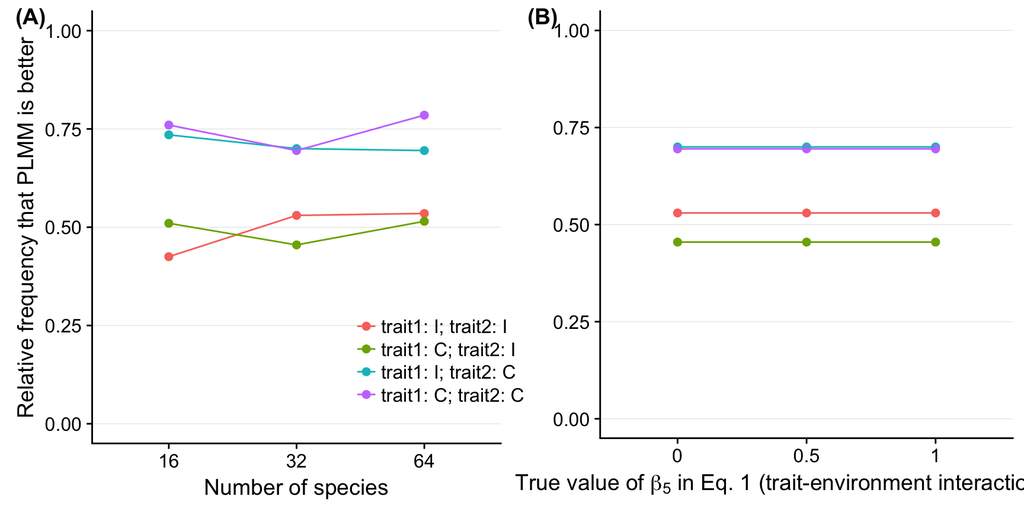

```r
better_1_plot = filter(prop_better1, Models == "PLMM better") %>%
  ggplot(aes(x = nspp, y = prop, color = catg, group = catg)) +
  geom_point(size = 2) + geom_line() + ylim(0, 1) +
  labs(y = "Relative frequency that PLMM is better",
       x = "Number of species") +
  theme(legend.title = element_blank(), legend.position = c(0.85, 0.20)) +
  background_grid(major = "y", minor = "none")

better_2_plot = filter(prop_better2, Models == "PLMM better") %>%
  ggplot(aes(x = real.val, y = prop, color = catg, group = catg)) +
  geom_point(size = 2) + geom_line() + ylim(0, 1) +
  labs(x = expression(paste("True value of ", beta[5],
                            " in Eq. 1 (trait-environment interaction term)")),
       y = "") +
  theme(legend.position = "none")+
  background_grid(major = "y", minor = "none")

plot_grid(better_1_plot, better_2_plot, labels = c("(A)", "(B)"))
```

## Figure 2

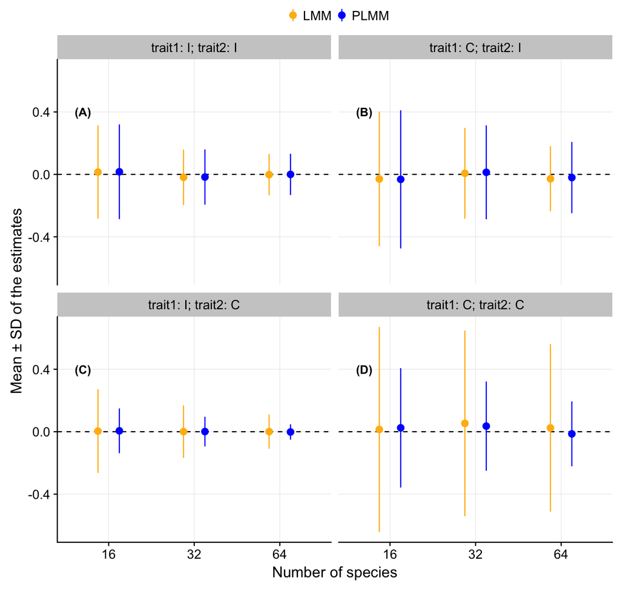

```r
fig2_p = ggplot(mutate(type_errs, nspp = as.character(nspp)),
                aes(x = nspp, y = ave.est, group = models, color = models)) +
  geom_hline(yintercept = 0, linetype = 2) +
  geom_pointrange(aes(ymin = ave.est.low, ymax = ave.est.high),
                  position = position_dodge(width = 0.5)) +
  facet_wrap(~catg) +
  theme(legend.position = "top", legend.title = element_blank()) +
  background_grid(major = "xy", minor = "none") +
  labs(x = "Number of species",
       y = "Mean ± SD of the estimates") +
  scale_color_manual(values = c("darkgoldenrod1", "blue"))
dat = data.frame(x = rep(0.7, 4), y = rep(0.4, 4), catg = factor(unique(type_errs$catg),
                                                                 levels = c("trait1: I; trait2: I",
                                                                            "trait1: C; trait2: I",
                                                                            "trait1: I; trait2: C",
                                                                            "trait1: C; trait2: C")),
                 labs = c("(A)", "(C)", "(B)", "(D)"), models = "LMM")
fig2_p + geom_text(aes(x, y, label = labs, group = NULL), data = dat, color = "black", fontface = "bold")
```

## Figure 3

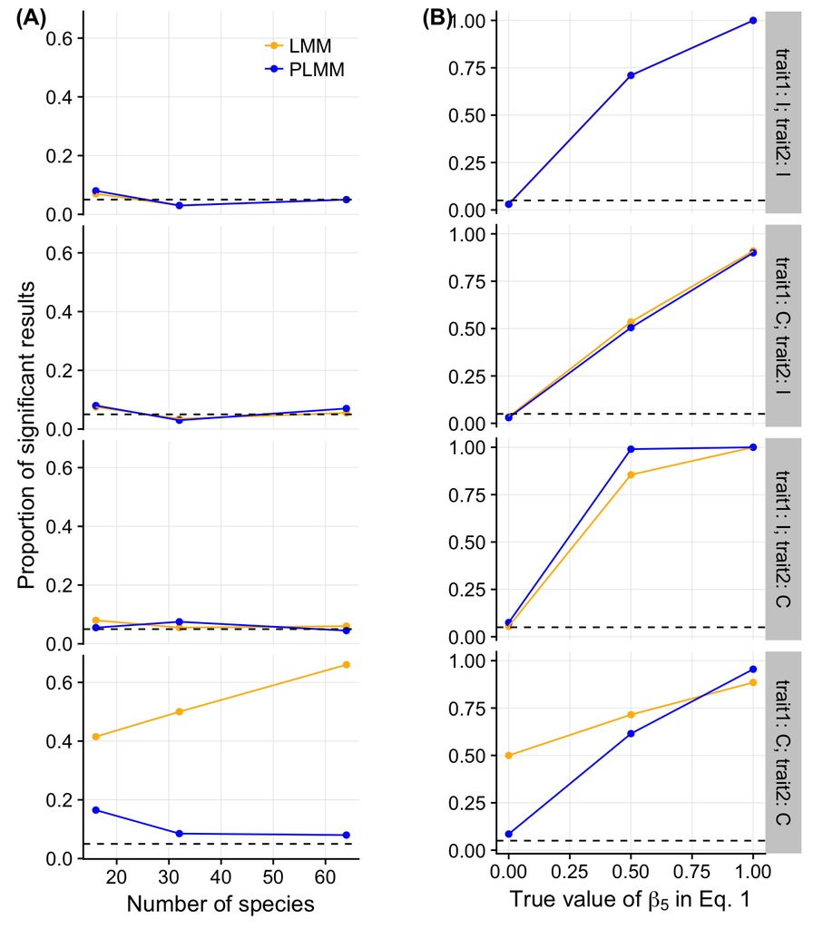

```r
type_1_plot = ggplot(type_errs,
                     aes(x = nspp, y = reject.prop, color = models)) +
  geom_point() + geom_line() +
  geom_hline(yintercept = 0.05, linetype = 2) +
  facet_grid(catg~.) +
  theme(legend.position = c(0.8, 0.95),
        legend.title = element_blank(),
        strip.background = element_blank(),
        # panel.border = element_rect(color = "white"),
        strip.text.y = element_text(color = "white")) +
  background_grid(major = "xy", minor = "none") +
  labs(x = "Number of species",
       y = "Proportion of significant results") +
  scale_color_manual(values = c("darkgoldenrod1", "blue"))

type_2_plot = ggplot(type_errs2,
                     aes(x = beta5, y = reject.prop, color = trt)) +
  geom_point() + geom_line() +
  geom_hline(yintercept = 0.05, linetype = 2) +
  facet_grid(catg ~ .) +
  theme(legend.position = "null") +
  labs(x = expression(paste("True value of ", beta[5],
                            " in Eq. 1")),
       y = "") +
  background_grid(major = "xy", minor = "none")+
  scale_color_manual(values = c("darkgoldenrod1", "blue"))

plot_grid(type_1_plot, type_2_plot, labels = c("(A)", "(B)"))
```

## Figure 4

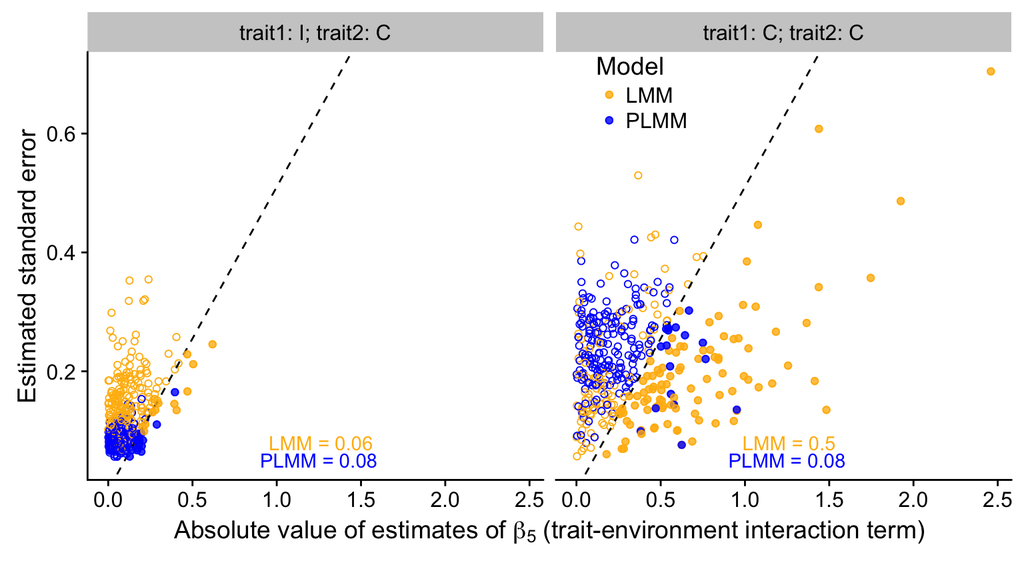

```r
est_se_plt(nsp = 32, alpha = 0.8, trait2_C = T, text1_x = 1.263, text2_x = 1.25, text1_y = 0.08)
```

### Figure A1

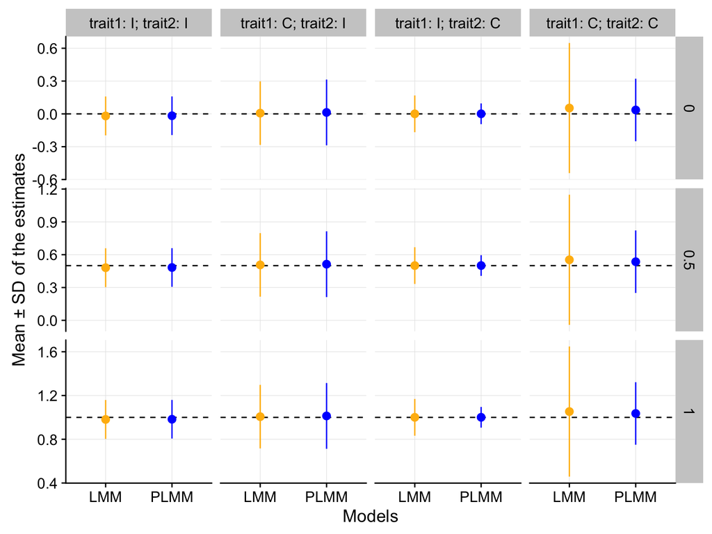

```r
ggplot(type_errs2,
       aes(x = models, y = ave.est, color = models)) +
  geom_hline(aes(yintercept = beta5), linetype = 2) +
  geom_pointrange(aes(ymin = ave.est.low, ymax = ave.est.high)) +
  facet_grid(beta5~catg, scales = "free") +
  labs(x = "Models",
       y = "Mean ± SD of the estimates") +
  theme(legend.position = "null") +
  background_grid(major = "xy", minor = "none") +
  scale_color_manual(values = c("darkgoldenrod1", "blue"))
```

### Figure A2

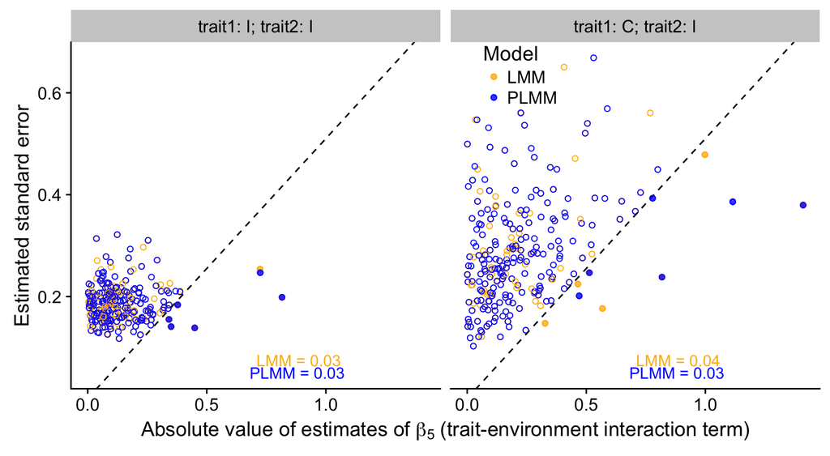

```r
est_se_plt(nsp = 32, alpha = 0.8, trait2_C = F, text1_x = 0.886, text2_x = 0.88, text1_y = 0.075)
```

# Varing death rates of phylogenies

We have conducted simulations with different extinction rates (`death_rate = c(0.1, 0.3, 0.5, 0.7)`) and different number of species (`nspp = c(20, 40, 60)`) in the simple birth-death model. For each extinction rate and number of species combination, we conducted 200 simulations with `nsite = 30` and `trait1: C; trait2: C`. We then compared type I errors of LMM and PLMM, which is the most important information in the manuscript. We found that the extinction rates do not affect our conclusions.

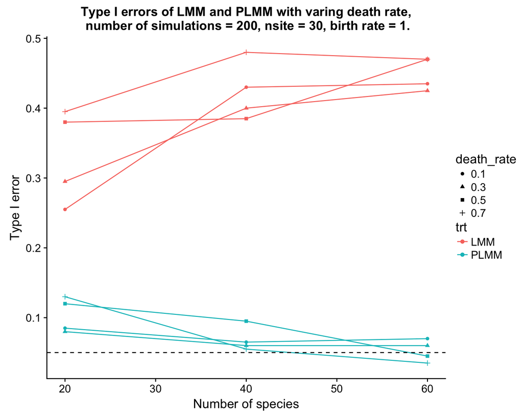

```r
test1 = bind_rows(
readRDS("rds_var_bd/sp20site30_birth1death0.1_11.rds")$est.fixed.eff %>% mutate(nspp = 20, death_rate = 0.1) %>% filter(terms == "envi1:trait1"),
readRDS("rds_var_bd/sp40site30_birth1death0.1_11.rds")$est.fixed.eff %>% mutate(nspp = 40, death_rate = 0.1) %>% filter(terms == "envi1:trait1"),
readRDS("rds_var_bd/sp60site30_birth1death0.1_11.rds")$est.fixed.eff %>% mutate(nspp = 60, death_rate = 0.1) %>% filter(terms == "envi1:trait1"),
readRDS("rds_var_bd/sp20site30_birth1death0.3_11.rds")$est.fixed.eff %>% mutate(nspp = 20, death_rate = 0.3) %>% filter(terms == "envi1:trait1"),
readRDS("rds_var_bd/sp40site30_birth1death0.3_11.rds")$est.fixed.eff %>% mutate(nspp = 40, death_rate = 0.3) %>% filter(terms == "envi1:trait1"),
readRDS("rds_var_bd/sp60site30_birth1death0.3_11.rds")$est.fixed.eff %>% mutate(nspp = 60, death_rate = 0.3) %>% filter(terms == "envi1:trait1"),
readRDS("rds_var_bd/sp20site30_birth1death0.5_11.rds")$est.fixed.eff %>% mutate(nspp = 20, death_rate = 0.5) %>% filter(terms == "envi1:trait1"),
readRDS("rds_var_bd/sp40site30_birth1death0.5_11.rds")$est.fixed.eff %>% mutate(nspp = 40, death_rate = 0.5) %>% filter(terms == "envi1:trait1"),
readRDS("rds_var_bd/sp60site30_birth1death0.5_11.rds")$est.fixed.eff %>% mutate(nspp = 60, death_rate = 0.5) %>% filter(terms == "envi1:trait1"),
readRDS("rds_var_bd/sp20site30_birth1death0.7_11.rds")$est.fixed.eff %>% mutate(nspp = 20, death_rate = 0.7) %>% filter(terms == "envi1:trait1"),
readRDS("rds_var_bd/sp40site30_birth1death0.7_11.rds")$est.fixed.eff %>% mutate(nspp = 40, death_rate = 0.7) %>% filter(terms == "envi1:trait1"),
readRDS("rds_var_bd/sp60site30_birth1death0.7_11.rds")$est.fixed.eff %>% mutate(nspp = 60, death_rate = 0.7) %>% filter(terms == "envi1:trait1")) %>%
  tbl_df()

group_by(test1, nspp, death_rate, trt) %>% summarise(n_sig = mean(Pvalue < 0.05)) %>%
  ungroup() %>%
  mutate(trt = revalue(trt, c("no_phylo" = "LMM", "phylo" = "PLMM")),
         death_rate = as.factor(death_rate)) %>%
  ggplot(aes(x = nspp, y = n_sig, color = trt, shape = death_rate)) +
  geom_point() + geom_line() + geom_hline(yintercept = 0.05, linetype = 2) +
  labs(x = "Number of species", y = "Type I error", title = "Type I errors of LMM and PLMM with varing death rate,\n number of simulations = 200, nsite = 30, birth rate = 1.")
```